# Skalenhandbuch_abiturma_survey_fr_16 Gruppe 2

Simone Poindl

26 September 2016

# Data Import

```r
library(stargazer)
library(dplyr)
library(pander)
library(psych)
library(knitr)
library(gridExtra)
library(ggplot2)



library(readr)
data_abiturma <- read_delim("data_abiturma_2016-08-04_12-45.csv",
                                             "|", escape_double = TRUE
                                             )

data_abiturma_ol <- read_delim("data_abiturma_2016-08-04_12-45_ol.csv",
                                             "|", escape_double = TRUE
                                             )
data_abiturma_ol <- data_abiturma_ol[7:nrow(data_abiturma_ol), ]
```

# Skalenhandbuch zum Fragebogen Gruppe 2

## Geschlecht

- **Frageprompt:** Welches Geschlecht hast du?
- **Anzahl der Items:** 1
- **Antwortformat:** Einfachauswahl
- **Antwortkategorien:**
  - 1 = weiblich
  - 2 = männlich
  - 3 = anderes
- **Variablenbezeichnung:** SD01
- **Variablenart:** kategorial

| Geschlecht | Anzahl |
| --- | --- |
| weiblich | 27 |
| männlich | 48 |
| anderes | 0 |
| ungültig | 8 |

## Alter

- **Frageprompt:** Wie alt bist du?
- **Anzahl der Items:** 1
- **Antwortformat:** offen
- **Variablenbezeichnung:** SD02_01
- **Variablenart:** metrisch

|  | n | min | max | mean | sd |
| --- | --- | --- | --- | --- | --- |
| **SD02_01** | 74 | 18 | 48 | 24.16 | 4.871 |

## Erfahrung mit Einzel- oder Kleingruppennachhilfe in Mathe

- **Frageprompt:** Wie viele Stunden hast du (ungefähr) bereits Einzel- oder Kleingruppennachhilfe in Mathe gegeben?
- **Anzahl der Items:** 1
- **Antwortformat:** offen
- **Variablenbezeichnung:** SD04_01
- **Variablenart:** metrisch

|  | n | min | max | mean | sd |
| --- | --- | --- | --- | --- | --- |
| **SD04_01** | 70 | 0 | 1000 | 126.5 | 181.4 |

## Erfahrung mit Matheunterricht für Kurse/Gruppen außerhalb von abiturma

- **Frageprompt:** Wie viele Stunden hast Du (ungefähr) außerhalb deiner Arbeit bei abiturma Kurse/Gruppen in Mathe unterrichtet?
- **Anzahl der Items:** 1
- **Antwortformat:** offen
- **Variablenbezeichnung:** SD07_01
- **Variablenart:** metrisch

|  | n | min | max | mean | sd |
| --- | --- | --- | --- | --- | --- |
| **SD07_01** | 69 | 0 | 1000 | 236.2 | 222.5 |

## Anzahl der bereits geleiteten abiturma Kurse

- **Frageprompt:** Wie viele aniturma-Kurse hast du vor diesem Kursdurchlauf bei abiturma bereits geleitet?
- **Anzahl der Items:** 1
- **Antwortformat:** offen
- **Variablenbezeichnung:** SD05_01
- **Variablenart:** metrisch

|  | n | min | max | mean | sd |
| --- | --- | --- | --- | --- | --- |
| **SD05_01** | 73 | 0 | 10 | 0.9041 | 1.819 |

## Aktueller beruflicher Status

- **Frageprompt:** Welchen beruflichen Status hast du aktuell?
- **Anzahl der Items:** 4
- **Antwortformat:** Einfachwahl und offen
- **Antwortkategorien:**
  - 1 = Student/in
  - 2 = Dktorand/in
  - 3 = Berufstätig
  - 4 = Sonstiges
- **Variablenbezeichnung:** SD06_01 (SD06_04)
- **Variablenart:** kategorial

[output not shown]

## Gewonnene Erkenntnisse der KursleiterIinnen aus den gesichteten Rückmeldungen

- **Frageprompt:** Welche Erkenntnisse hast du für Dich aus den eben gesichteten Rückmeldungen der Kursteilnehmer/innen gewinnen können??
- **Anzahl der Items:** 1
- **Antwortformat**: offen
- **Variablenbezeichnung:** FB09_01

## Informativität der Rückmeldeformate

- **Frageprompt:** Wie informativ waren die folgenden Rückmeldeformate für dich?
- **Anzahl der Items:** 3
- **Antwortformat:** Ratingskala
- **Antwortkategorien:** 1 = kaum informativ bis 6 = sehr informativ
- **Variablenbezeichnung:**
  - Einzelantworten: FB02_06
  - Qualitätsdimensionen: FB02_05
  - Freitextantworten: FB02_07
- **Variablenart:** ordinal

**Gesamte Stichprobe:**

|  | n | min | max | mean | sd |
| --- | --- | --- | --- | --- | --- |
| **FB02_06** | 78 | 2 | 6 | 4.936 | 1.011 |
| **FB02_05** | 77 | 1 | 6 | 4.623 | 1.203 |
| **FB02_07** | 76 | 1 | 6 | 4.724 | 1.323 |

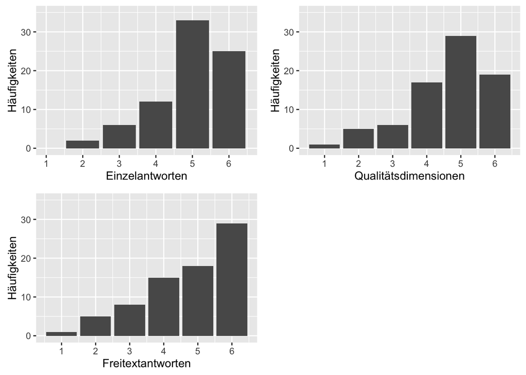

**Gruppe 1:**

|  | n | min | max | mean | sd |
| --- | --- | --- | --- | --- | --- |
| **FB02_06** | 39 | 3 | 6 | 5.308 | 0.731 |
| **FB02_05** | 39 | 1 | 6 | 4.641 | 1.347 |
| **FB02_07** | 38 | 2 | 6 | 4.816 | 1.182 |

**Gruppe 2:**

|  | n | min | max | mean | sd |
| --- | --- | --- | --- | --- | --- |
| **FB02_06** | 39 | 2 | 6 | 4.564 | 1.119 |
| **FB02_05** | 38 | 2 | 6 | 4.605 | 1.054 |
| **FB02_07** | 38 | 1 | 6 | 4.632 | 1.46 |

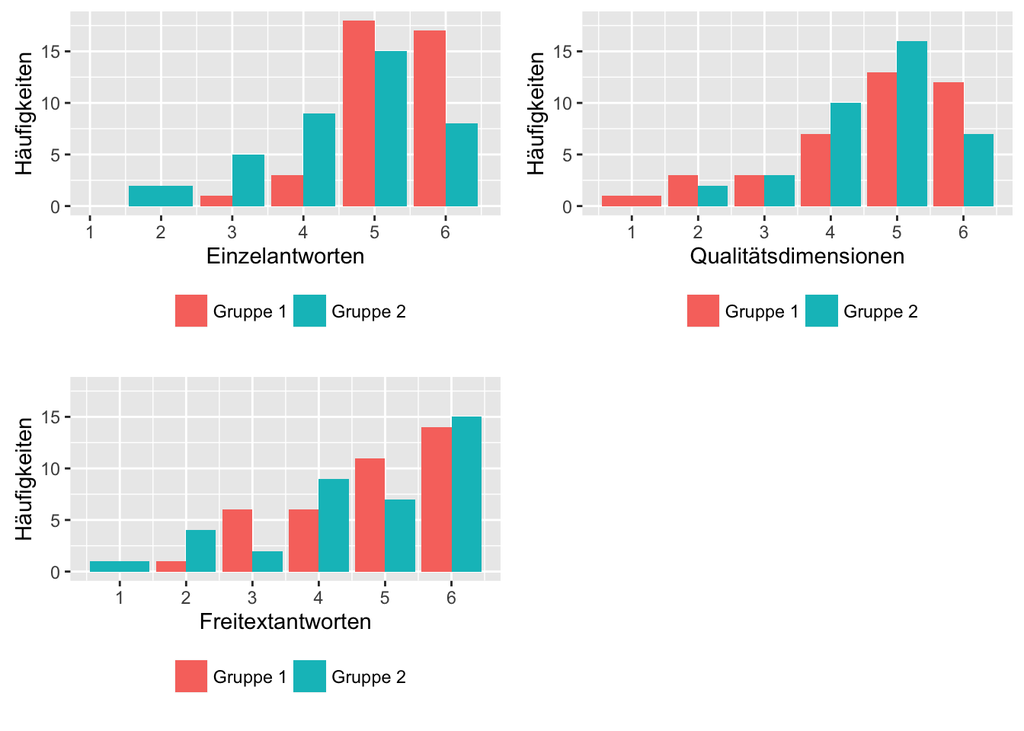

## Informativität der einzelnen Qualitätsdimensionen

- **Frageprompt:** Wie informativ waren die einzelnen Qualitätsdimensionen für dich?
- **Anzahl der Items:** 5
- **Antwortformat:** Ratingskala
- **Antwortkategorien:** 1 = kaum informativ bis 6 = sehr informativ
- **Variablenbezeichnung:**
  - Lernerfolg: FB03_01
  - Enthusiasmus: FB03_02
  - Organisation: FB03_03
  - Gruppeninteraktion: FB03_04
  - Individuelle Beziehung: FB03_05
- **Variablenart:** ordinal

**Gesamte Stichprobe:**

[output not shown]

[figure not shown]

**Gruppe 1:**

|  | n | min | max | mean | sd |
| --- | --- | --- | --- | --- | --- |
| **FB03_01** | 40 | 1 | 6 | 5.025 | 1.165 |
| **FB03_02** | 40 | 2 | 6 | 4.875 | 0.9658 |
| **FB03_03** | 40 | 3 | 6 | 5.025 | 0.8619 |
| **FB03_04** | 40 | 2 | 6 | 4.825 | 1.059 |
| **FB03_05** | 40 | 3 | 6 | 4.95 | 0.8756 |

**Gruppe 2:**

|  | n | min | max | mean | sd |
| --- | --- | --- | --- | --- | --- |
| **FB03_01** | 39 | 1 | 6 | 4.41 | 1.332 |
| **FB03_02** | 39 | 3 | 6 | 4.923 | 0.7393 |
| **FB03_03** | 39 | 2 | 6 | 4.41 | 1.208 |
| **FB03_04** | 39 | 2 | 6 | 4.718 | 1.075 |
| **FB03_05** | 39 | 2 | 6 | 5.179 | 0.9423 |

## Informativität der verschiedenen Schaubilder

|  | n | min | max | mean | sd |
| --- | --- | --- | --- | --- | --- |
| **FB13_01** | 39 | 1 | 6 | 4.41 | 1.208 |
| **FB13_02** | 37 | 1 | 6 | 4.595 | 1.279 |
| **FB13_03** | 39 | 2 | 6 | 4.282 | 1.234 |
| **FB13_04** | 39 | 1 | 6 | 4.897 | 1.252 |

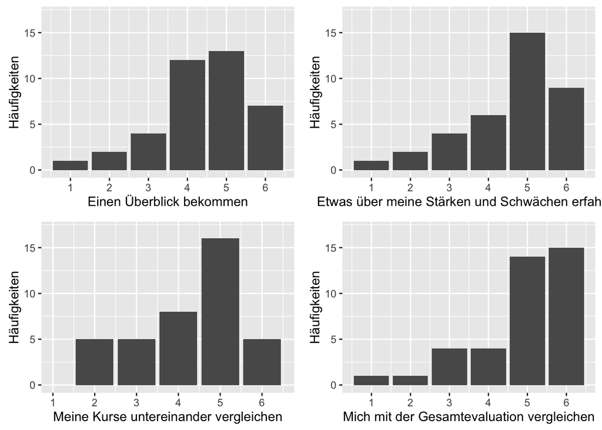

## Inhaltliche Interpretationssicherheit bei den jeweiligen Schaubildern

- **Frageprompt:** Wie sicher warst Du bei der inhaltlichen Interpretation der jeweiligen Schaubilder?
- **Anzahl der Items:** 4
- **Antwortformat:** Ratingskala
- **Antwortkategorien:** 1 = kaum informativ bis 6 = sehr informativ
- **Variablenbezeichnung:**
  - einen Überblick bekommen: FB14_01
  - etwas über meine Stärken und Schwächen erfahren: FB14_03
  - meine Kurse untereinander vergeleichen: FB14_02
  - mich mit der Gesamtevaluation vergleichen: FB14_04
- **Variablenart:** ordinal

|  | n | min | max | mean | sd |
| --- | --- | --- | --- | --- | --- |
| **FB14_01** | 39 | 1 | 6 | 4.821 | 1.233 |
| **FB14_03** | 39 | 1 | 6 | 4.59 | 1.208 |
| **FB14_02** | 39 | 2 | 6 | 4.974 | 1.158 |
| **FB14_04** | 39 | 1 | 6 | 4.744 | 1.229 |

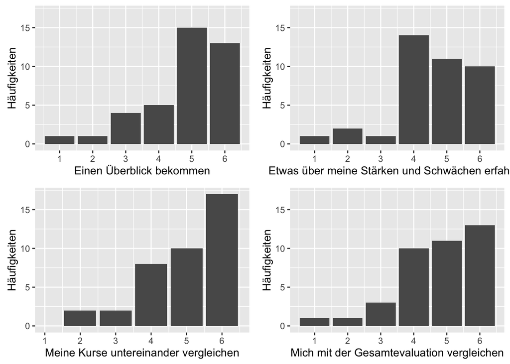

## Informativität der verschiedenen Darstellungen

- **Frageprompt:** Wie informativ waren die verschiedenen Darstellungen für dich?
- **Anzahl der Items:** 4
- **Antwortformat:** Ratingskala
- **Antwortkategorien:** 1 = kaum informativ bis 6 = sehr informativ
- **Variablenbezeichnung:**
  - Dimensioneswerte je Teilnehmer: FB17_04
  - Mittelwerte der Dimensionswerte: FB17_01
  - Quartile: FB17_02
  - 95%-Konfidenzintervall: FB17_03
- **Variablenart:** ordinal

|  | n | min | max | mean | sd |
| --- | --- | --- | --- | --- | --- |
| **FB17_04** | 36 | 1 | 6 | 3.861 | 1.355 |
| **FB17_01** | 36 | 2 | 6 | 4.833 | 1.231 |
| **FB17_02** | 36 | 1 | 6 | 4.222 | 1.396 |
| **FB17_03** | 36 | 1 | 6 | 4.361 | 1.397 |

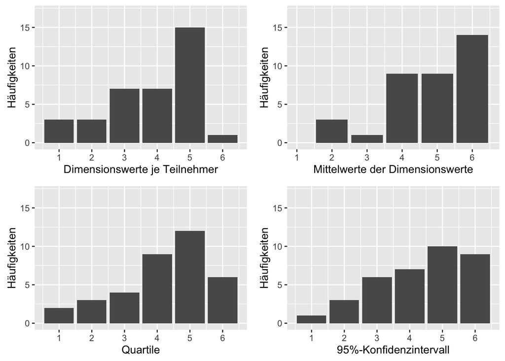

## Inhaltliche Interpretationssicherheit bei den verschiedenen Darstellungen

- **Frageprompt:** Wie sicher warst du bei der inhaltlichen Interpretation der verschiedenen Darstellungen?
- **Anzahl der Items:** 4
- **Antwortformat:** Ratingskala
- **Antwortkategorien:** 1 = kaum informativ bis 6 = sehr informativ
- **Variablenbezeichnung:**
  - Dimensioneswerte je Teilnehmer: FB18_04
  - Mittelwerte der Dimensionswerte: FB18_01
  - Quartile: FB18_02
  - 95%-Konfidenzintervall: FB18_03
- **Variablenart:** ordinal

|  | n | min | max | mean | sd |
| --- | --- | --- | --- | --- | --- |
| **FB18_04** | 37 | 2 | 6 | 4.649 | 1.296 |
| **FB18_01** | 37 | 2 | 6 | 5.162 | 1.143 |
| **FB18_02** | 37 | 1 | 6 | 4.595 | 1.443 |
| **FB18_03** | 37 | 1 | 6 | 4.622 | 1.401 |

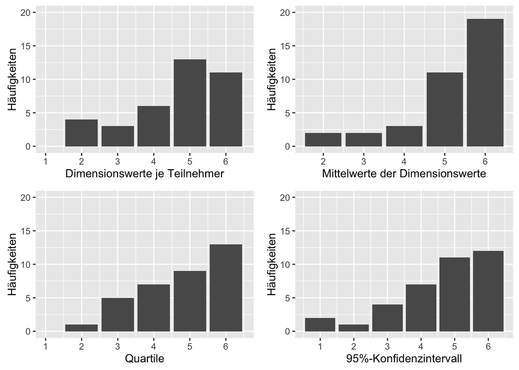

## Informativität verschiedener Skalierungen

- **Frageprompt:** Wie informativ waren die verschiedenen Skalierungen für dich??
- **Anzahl der Items:** 3
- **Antwortformat:** Ratingskala
- **Antwortkategorien:** 1 = kaum informativ bis 6 = sehr informativ
- **Variablenbezeichnung:**
  - Skala 1 (–) bis 7 (++): FB10_01
  - Mittetw. abiturma = 0 (je Dimension) : FB10_03
  - Mittelw. je TeilnehmerIn = 0: FB10_02
- **Variablenart:** ordinal

**Gesamte Stichprobe:**

|  | n | min | max | mean | sd |
| --- | --- | --- | --- | --- | --- |
| **FB10_01** | 73 | 1 | 6 | 5.014 | 1.112 |
| **FB10_03** | 73 | 1 | 6 | 4.726 | 1.387 |
| **FB10_02** | 73 | 1 | 6 | 3.849 | 1.459 |

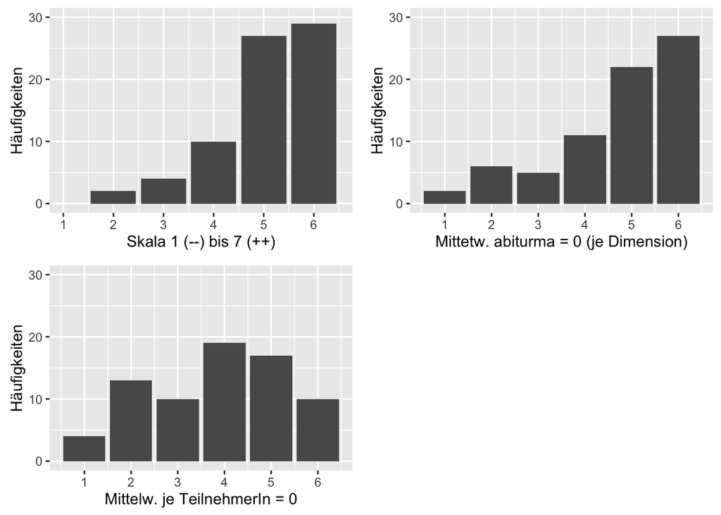

**Gruppe 1:**

|  | n | min | max | mean | sd |
| --- | --- | --- | --- | --- | --- |
| **FB10_01** | 37 | 1 | 6 | 4.892 | 1.286 |
| **FB10_03** | 37 | 1 | 6 | 4.514 | 1.592 |
| **FB10_02** | 37 | 1 | 6 | 3.676 | 1.51 |

**Gruppe 2:**

|  | n | min | max | mean | sd |
| --- | --- | --- | --- | --- | --- |
| **FB10_01** | 36 | 3 | 6 | 5.139 | 0.8993 |
| **FB10_03** | 36 | 2 | 6 | 4.944 | 1.12 |
| **FB10_02** | 36 | 1 | 6 | 4.028 | 1.404 |

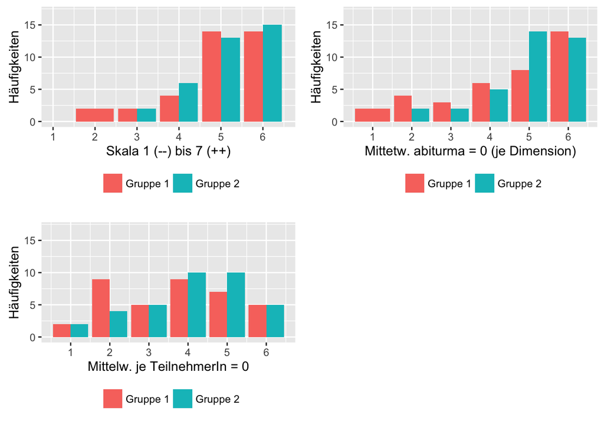

## Inhaltliche Interpretationssicherheit der verschiedenen Skalierungen

- **Frageprompt:** Wie sicher warst Du bei der inhaltlichen Interpretation der verschiedenen Skalierungen?
- **Anzahl der Items:** 3
- **Antwortformat:** Ratingskala
- **Antwortkategorien:** 1 = kaum informativ bis 6 = sehr informativ
- **Variablenbezeichnung:**
  - Skala 1 (–) bis 7 (++): FB11_01
  - Mittetw. abiturma = 0 (je Dimension) : FB11_02
  - Mittelw. je TeilnehmerIn = 0: FB11_03
- **Variablenart:** ordinal

**Gesamte Stichprobe:**

|  | n | min | max | mean | sd |
| --- | --- | --- | --- | --- | --- |
| **FB11_01** | 73 | 2 | 6 | 5.26 | 1.041 |
| **FB11_02** | 72 | 2 | 6 | 4.958 | 1.215 |
| **FB11_03** | 72 | 1 | 6 | 4.306 | 1.45 |

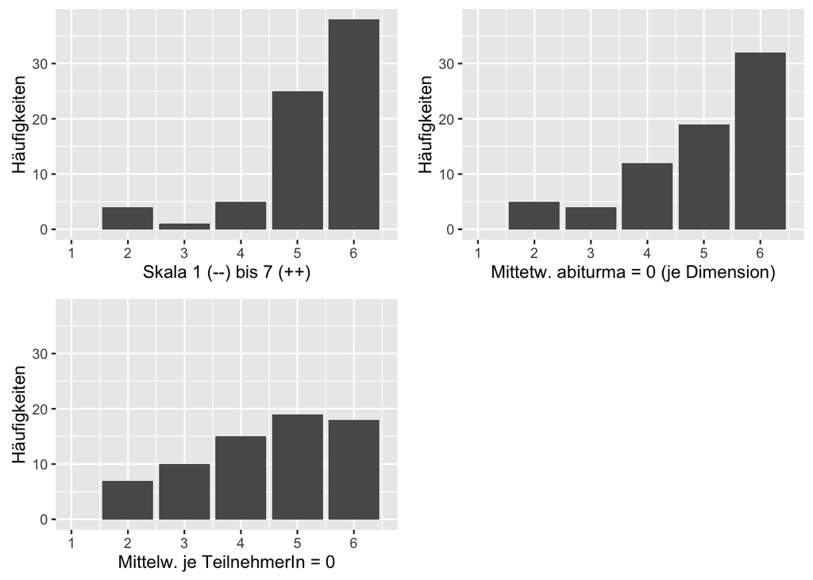

**Gruppe 1:**

|  | n | min | max | mean | sd |
| --- | --- | --- | --- | --- | --- |
| **FB11_01** | 37 | 2 | 6 | 5.108 | 1.286 |
| **FB11_02** | 36 | 2 | 6 | 4.917 | 1.273 |
| **FB11_03** | 36 | 1 | 6 | 4.222 | 1.57 |

**Gruppe 2:**

|  | n | min | max | mean | sd |
| --- | --- | --- | --- | --- | --- |
| **FB11_01** | 36 | 3 | 6 | 5.417 | 0.6918 |
| **FB11_02** | 36 | 2 | 6 | 5 | 1.171 |
| **FB11_03** | 36 | 1 | 6 | 4.389 | 1.337 |

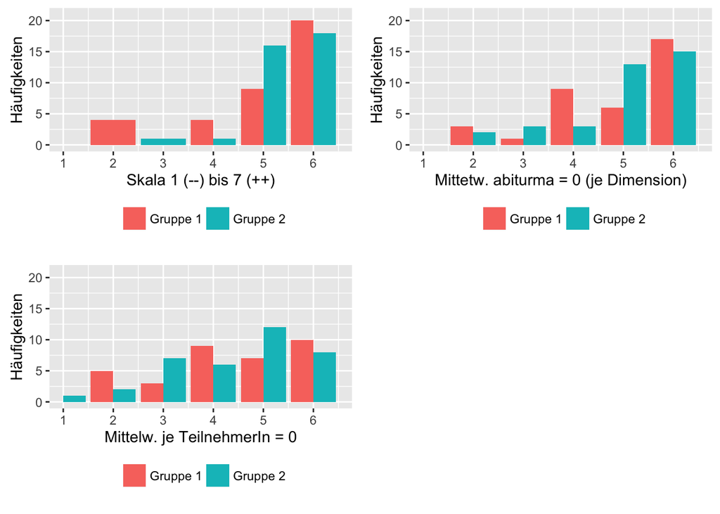